# Analysis of Restaurant Tips Dataset

Ozan Tivriz

2025-11-01

This is an analysis of a restaurant and its customers, aimed at understanding the relationship between tips, group sizes, and days.

## Importing Data

```r
library(tidyverse)
tips <- read.csv("restaurant_tips/tip.csv")
```

## Cleaning Data

When we look at the day column in the data, there is only 4 inputs.

```r
table(tips$day)
```

```
##
##  Fri  Sat  Sun Thur
##   19   87   76   62
```

We assume that the restaurant is only open for four days a week and rename the days for a cleaner look. A new data frame is created to avoid affecting the original dataset.

```r
tips_v2 <- tips %>%
  mutate(day = recode(day,
                       "Fri" = "Friday",
                       "Sat" = "Saturday",
                       "Sun" = "Sunday",
                       "Thur" = "Thursday"))
```

We also create a vector to order the days and attach this factor to our data.

```r
days <- c("Thursday","Friday","Saturday","Sunday")
tips_v2$day <- factor(tips_v2$day, levels = days)
```

There is also a sex column and a size column, which indicates how many people are dining together. To analyze tipping behavior by gender, we first need to create a new data frame containing only solo diners.

However, there are only four people who dined alone, so any analysis based on this data would be biased. Therefore, we decided not to include gender-specific analysis.

```r
table(tips_v2$size)
```

```
##
##   1   2   3   4   5   6
##   4 156  38  37   5   4
```

## Analyze

A new data frame is created to analyze the total bill. Many similar data frames will be created throughout this analysis, but for readability, we will not show every step to keep the report concise.

```r
mean_total_bill <- tips_v2 %>%
  group_by(size) %>%
  summarise(
    mean_total_bill = mean(total_bill),
    median_total_bill = median(total_bill)
  )
```

The bar chart illustrates how the average and median total bill change depending on the group size.

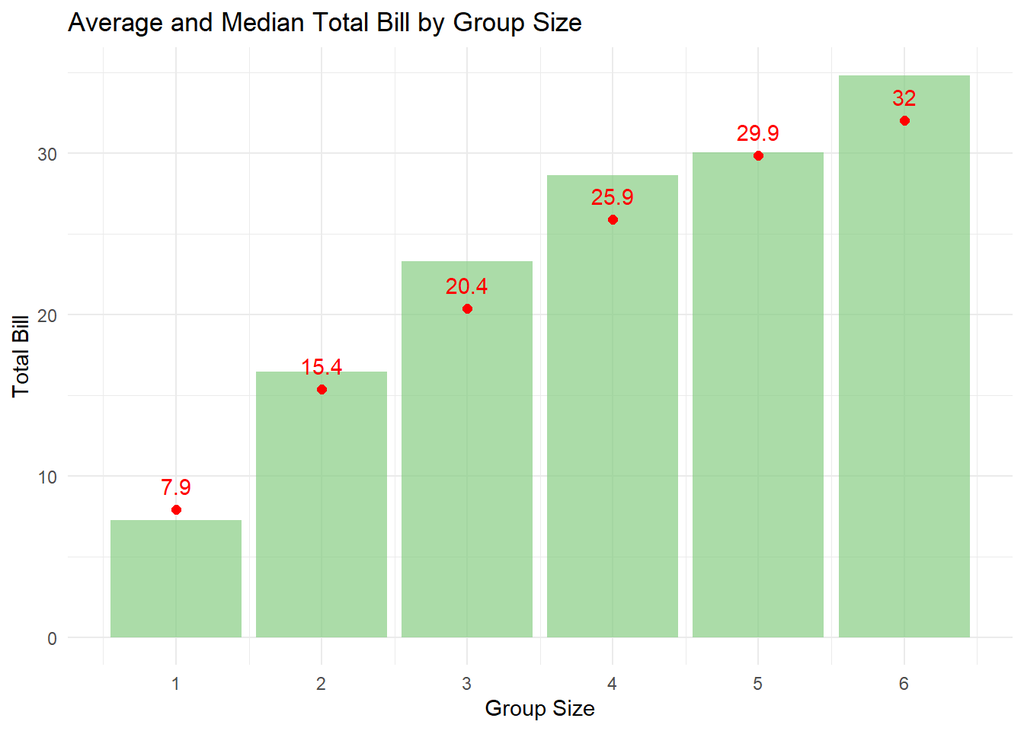

The bar chart illustrates how the average and median tips change depending on the group size.

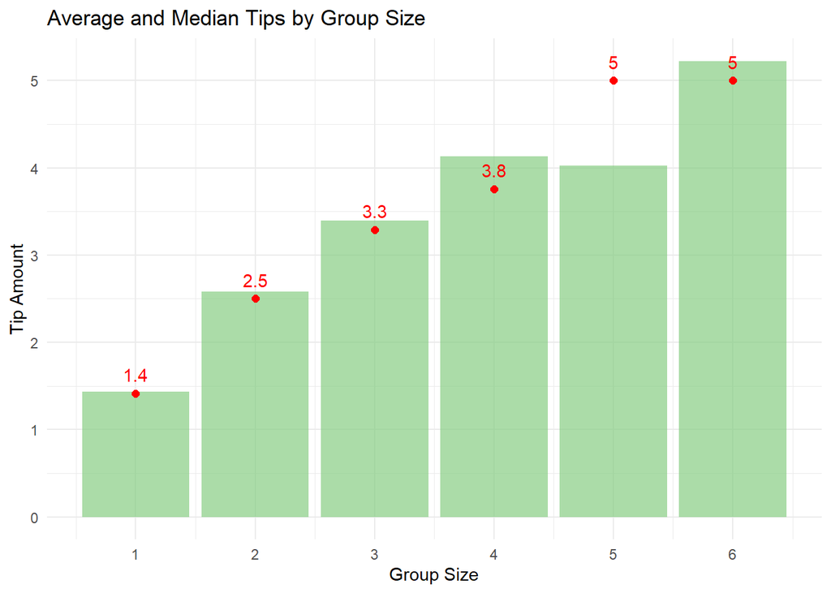

We also calculate and visualize the data based on the tip rate.

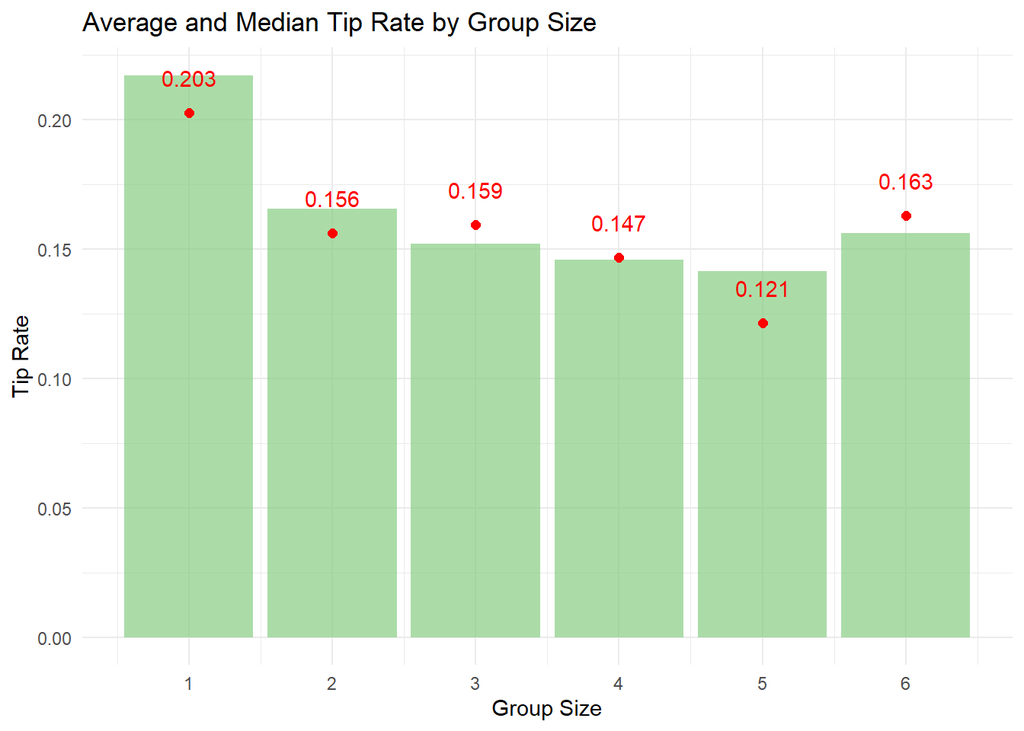

We first visualize the average per-person bill for each group size.

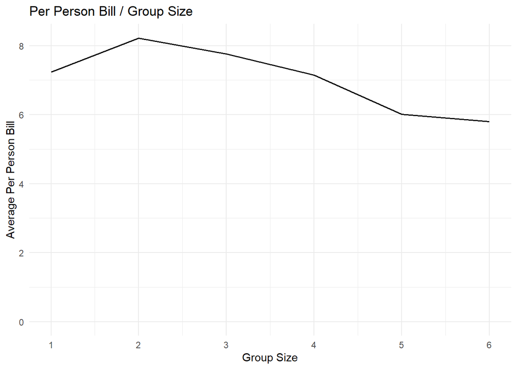

Next, we examine the individual per-person bills, showing their distribution and a linear trend line to capture the overall relationship.

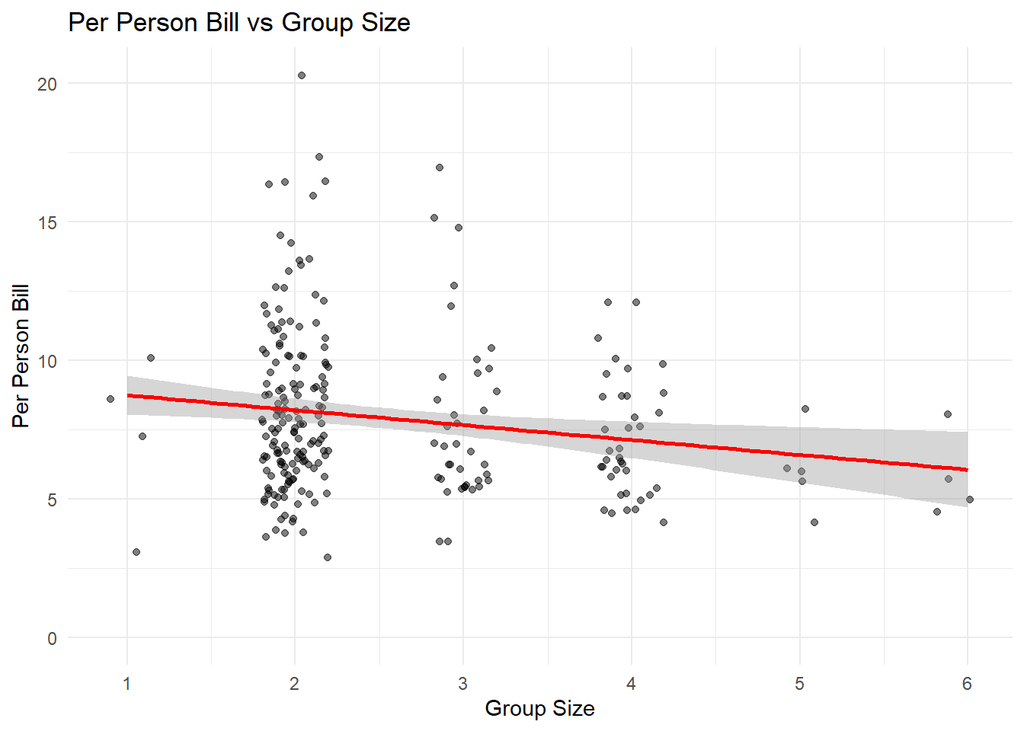

The correlation between group size and per-person bill is -0.175, which indicates a weak negative relationship. This suggests that, on average, as the group size increases, the amount each person pays slightly decreases.

```
## [1] -0.175412
```

The correlation between group size and tip amount is 0.489, indicating a moderate positive relationship. This suggests that larger groups tend to leave higher tips in absolute terms.

```
## [1] 0.4892988
```

With a correlation of -0.143, the tip rate slightly decreases as group size increases, showing a very weak negative relationship.

```
## [1] -0.1428596
```

To check for differences between days, we calculate the average and median tips for each day.

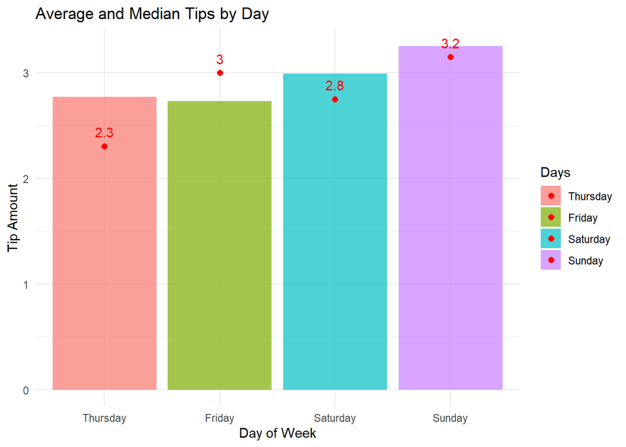

Looking at this graph, we can see that customer groups of more than two people are more likely to visit the restaurant on weekends.

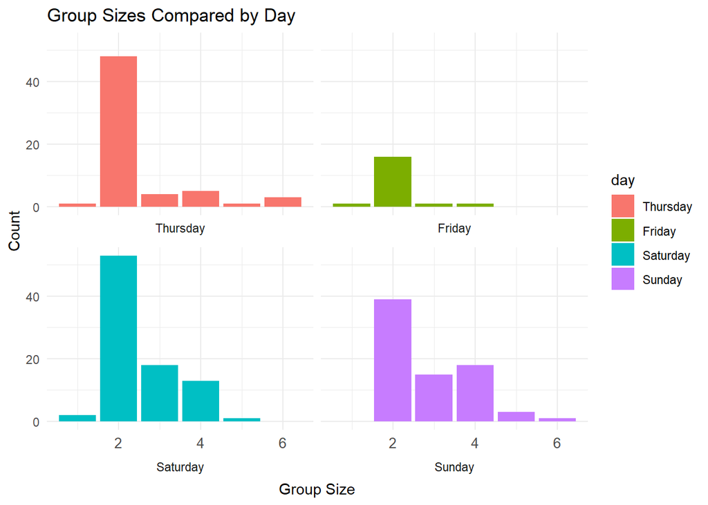

Here we compare customers by smokers and non-smokers.

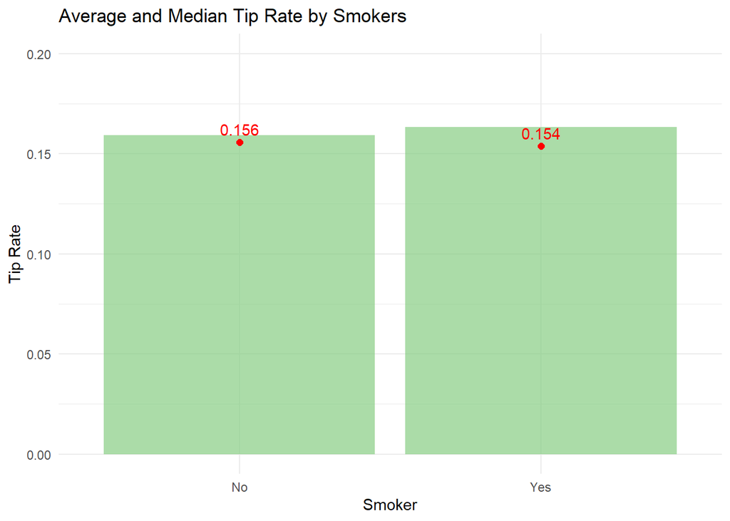

Smokers compared by day.

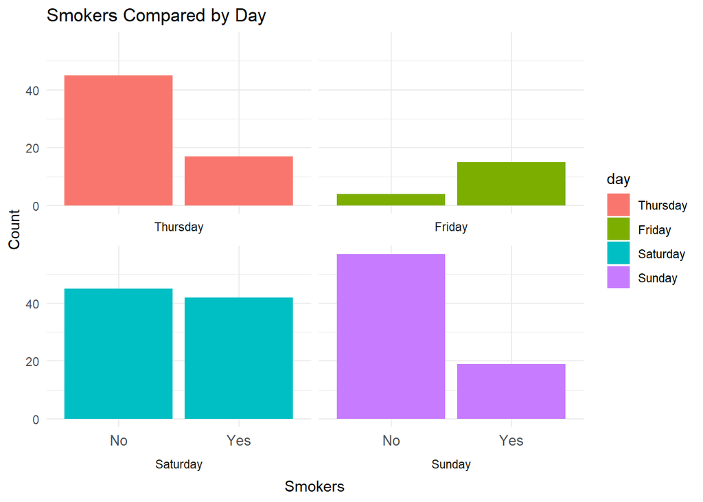

## Conclusion

* No strong correlations were observed between group size and total bill per person.

* As the group size increases, the total tip amount tends to increase; however, the tip rate slightly decreases, indicating that larger groups leave higher tips in absolute terms but slightly lower percentages of their total bill.

* Groups larger than two people are more likely to visit the restaurant on weekends.